# SMRU Consulting. Porpoise movement

adb

May 2024

# 1 Overview

This short document provides some details on the porpoise movement model developed as an alternative to assess harbour porpoise exposure to wind farms in the North Sea.

Code and data to reproduce the analyses summarized in this document can be found in [**this repository**](https://github.com/adbpatagonia/PorpoiseMovement).

# 2 Step length and turning angles

Nabe-Nielsen et al. (2013) presented distributions of step lengths and turning angles at a 30 minute resolution. The original data was collected at a frequency of 6 seconds in Wilson et al. (2007). Without having the original dataset, I am not sure how to scale up the distribution presented at 30-minute interval to a daily time scale.

I did a quick search and found three tagging studies for harbour porpoise:

- Read and Westgate (1997): tagged 9 porpoises in the Bay of Fundy and Gulf of Maine - data is available for 8 porpoises
- Nielsen et al. (2013): tagged two female porpoises in West Greenland - data available for both
- Sveegaard et al. (2011): tagged 64 harbour porpoises between 1997 and 2007, in order to determine the distribution in the North Sea, the western Baltic, and the waters in between. This dataset is used in several publications, but I could not find the data itself.

I harvested the data from the two papers that have available data, and compare below their distributions to the distribution of step length and turing angles presented in Stalder et al. (2020) (subset of 57 porpoises from the Sveegaard et al. (2011) study).

## 2.1 Stalder *et al.* 2020 data

Note that the data is data is:

- at a daily time step
- discriminated by behaviour:
  - Area-restricted movement
  - Directed movement
  - Uncertain

we will not discriminate by behaviour in this exercise, and therefore we only need one distribution that should resemble the mean daily movement

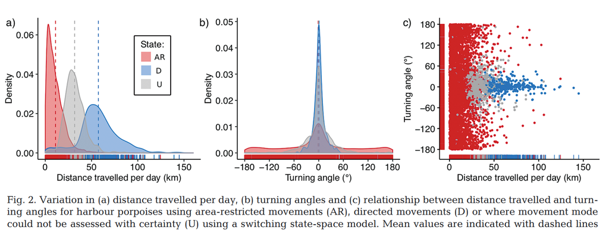

## 2.2 Harvested data

I created these distributions using data from Read and Westgate (1997) and Nielsen et al. (2013).

### 2.2.1 Step length

I extracted the `mean` and `var` of daily displacements from these data, and calculated the parameters of a gamma distribution as:

$$scale = Var(x)/E[x]$$
$$shape = E[x]^2/Var(x)$$
Using these parameters, I drew random step lengths from a gamma distribution.

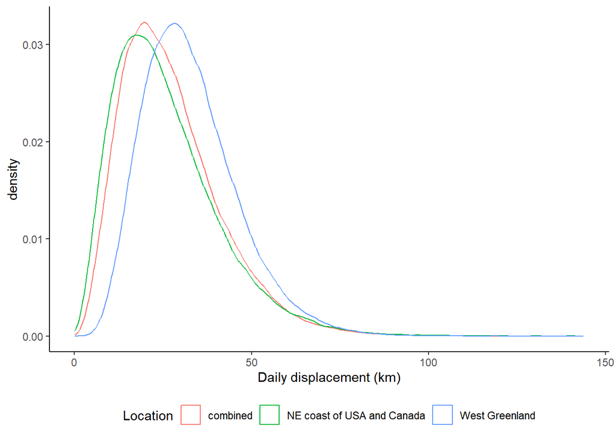

### 2.2.2 Turning Angle

I drew turning angles from a von Mises distribution. Given that the time step is daily, I allowed the agents to go in any direction (360°).

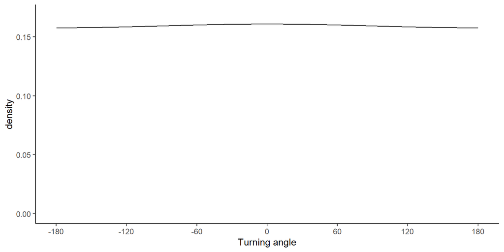

## 2.3 Comparison

At first sight, it seems like the distribution created from the harvested data resembles the distribution presented in Stalder et al. (2020). However, please note this passage from Nielsen et al. (2013): *“The average daily travel rates for the two harbour porpoises were 24 km (range 0.6 – 103 km, SD=21.9) and 42 km (range 1.9 – 118.7 km, SD=25.2), respectively, which are in the same range of harbour porpoises from Bay of Fundy (range 13.9 – 58.5 km, SD=13.9), Canada (Read & Westgate 1997) but slightly higher NAMMCO SC/20/HP/08 Harbour porpoise working group November 20133 than found for the North Sea (20.4 kmd-1) and the Baltic Sea (15.4 km d-1) (Sveegaard et al. 2011).”*

## 2.4 Conclusion

I think this means we have two options:

- use the distribution from the harvested data from Read and Westgate (1997) and Nielsen et al. (2013)
- reach out to Sveegaard and colleagues, and request the dataset - I am not sure of this is a possibility.

# References

Nabe-Nielsen, Jacob, Jakob Tougaard, Jonas Teilmann, Klaus Lucke, and Mads C. Forchhammer. 2013. “How a Simple Adaptive Foraging Strategy Can Lead to Emergent Home Ranges and Increased Food Intake.” *Oikos* 122 (9): 1307–16. https://doi.org/https://doi.org/10.1111/j.1600-0706.2013.00069.x.

Nielsen, Nynne .H., Rikke G. Hansen, Jonas Teilmann, and Mads Peter Heide-Jørgensen. 2013. “Extensive Offshore Movements of Harbour Porpoises (Phocoena Phocoena).” Harbour porpoise working group NAMMCO SC/20/HP/08.

Read, A. J., and A. J. Westgate. 1997. “Monitoring the Movements of Harbour Porpoises (Phocoena Phocoena) with Satellite Telemetry.” *Marine Biology* 130 (2): 315–22. https://doi.org/10.1007/s002270050251.

Stalder, D., van Beest FM, S. Sveegaard, R. Dietz, J. Teilmann, and J. Nabe-Nielsen. 2020. “Influence of Environmental Variability on Harbour Porpoise Movement.” *Mar Ecol Prog Ser* 648: 207–19. https://www.int-res.com/abstracts/meps/v648/p207-219/.

Sveegaard, Signe, Jonas Teilmann, Jakob Tougaard, Rune Dietz, Kim N. Mouritsen, Geneviève Desportes, and Ursula Siebert. 2011. “High-Density Areas for Harbor Porpoises (Phocoena Phocoena) Identified by Satellite Tracking.” *Marine Mammal Science* 27 (1): 230–46. https://doi.org/https://doi.org/10.1111/j.1748-7692.2010.00379.x.

Wilson, Rory P., Nikolai Liebsch, Ian M. Davies, Flavio Quintana, Henri Weimerskirch, Sandra Storch, Klaus Lucke, et al. 2007. “All at Sea with Animal Tracks; Methodological and Analytical Solutions for the Resolution of Movement.” *Deep Sea Research Part II: Topical Studies in Oceanography* 54 (3): 193–210. https://doi.org/https://doi.org/10.1016/j.dsr2.2006.11.017.